# lab8

## Lab 7 and 8

Kun Lee, partner: Lexie Peterson

```python
#Setup
%matplotlib inline
import numpy as np
import matplotlib
import matplotlib.pyplot as plt
import scipy
import scipy.signal
import math
from scipy import stats

plt.rcParams["figure.figsize"] = (20,15)

d = stats.norm.rvs(loc = 5., scale = 0.01, size = 100000)
plt.rcParams["figure.figsize"] = (50,50)

import pickle
infile = open("qcd_100000_pt_250_500.pkl",'rb')
qcd = pickle.load(infile)
qcd.keys()
```

```
Index(['pt', 'eta', 'phi', 'mass', 'ee2', 'ee3', 'd2', 'angularity', 't1',
       't2', 't3', 't21', 't32', 'KtDeltaR'],
      dtype='object')
```

```python
infile = open("higgs_100000_pt_250_500.pkl",'rb')
higgs = pickle.load(infile)
higgs.keys()
```

```
Index(['pt', 'eta', 'phi', 'mass', 'ee2', 'ee3', 'd2', 'angularity', 't1',
       't2', 't3', 't21', 't32', 'KtDeltaR'],
      dtype='object')
```

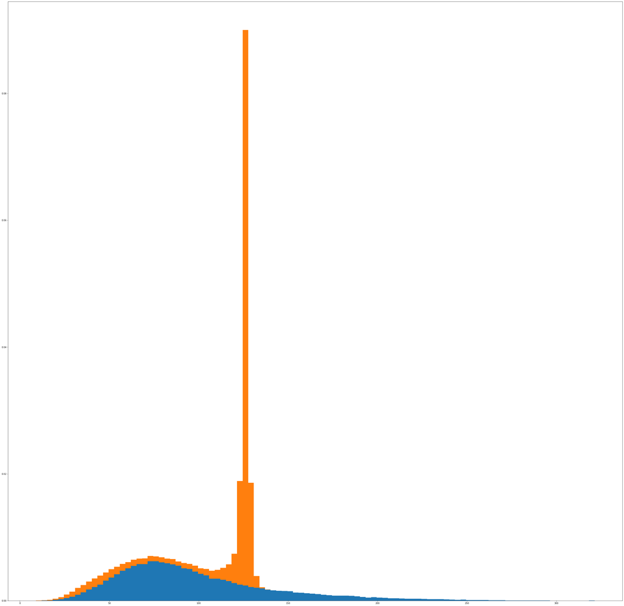

```python
fig, ax = plt.subplots(1,1)
list = [qcd["mass"], higgs["mass"]]
ax.hist(list, stacked=True, bins=100, density=True)
plt.show()
```

```python
higgs_mean = np.mean(higgs["mass"])
qcd_mean = np.mean(qcd["mass"])
scipy.stats.norm.isf(scipy.stats.poisson.sf(higgs_mean, qcd_mean))
```

```
1.6666117786402688
```

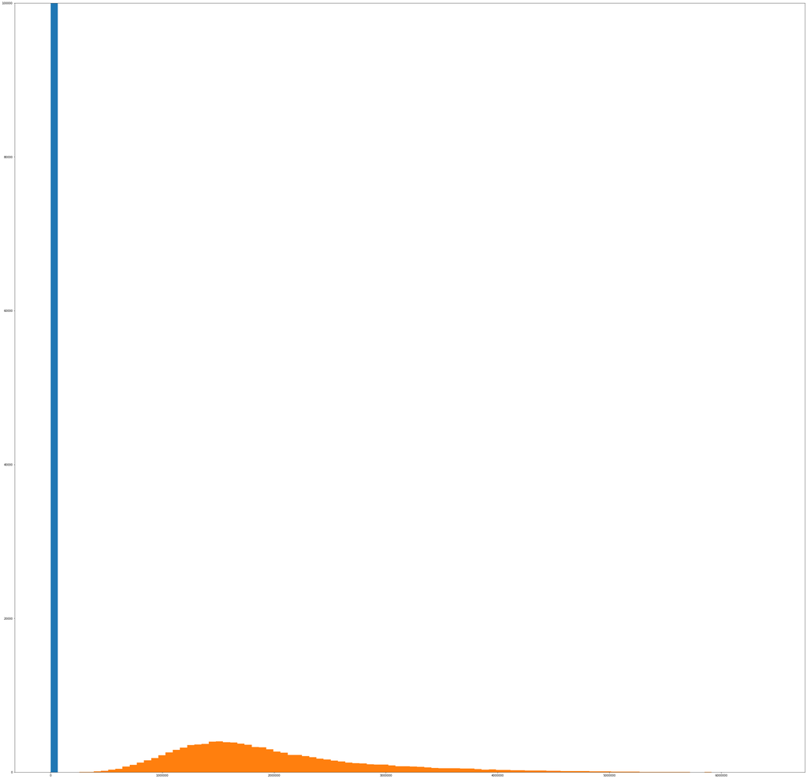

```python
norm_higgs = 100 * higgs["mass"]
norm_qcd = 20000 * qcd["mass"]
fig, ax = plt.subplots(1,1)
list = [norm_higgs, norm_qcd]
ax.hist(list, stacked=True, bins=100, density=False)
plt.show()
```

[output not shown]

```python
import math
100 / math.sqrt(20000)
```

```
0.7071067811865475
```

## Problem 2

```python
qcd_cut = []
for i in norm_qcd:
    if i > 1000000 and i < 2000000:
        qcd_cut.append(i)

len(qcd_cut)
```

```
53247
```

```python
norm_qcd.size
```

```
100000
```

```python
53427/100000*20000
```

```
10685.4
```

```python
100/math.sqrt(10685.4)
```

```
0.9673967139667404
```

Do cuts when histogram is normalized to 1. Find the area, which is a fraction of 1. So you multiply that by the expected yield to get the Nqcd.

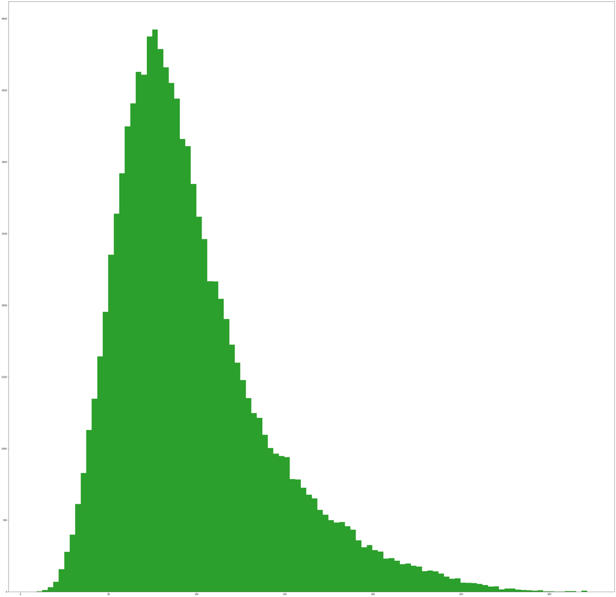

```python
norm_higgs = 100 * higgs["mass"]
norm_qcd = 20000 * qcd["mass"]
fig, ax = plt.subplots(1,1)
list = [qcd["mass"], higgs["mass"]]
x2 = ax.hist(list, stacked=True, bins=100, density=True)
x3 = ax.hist(qcd["mass"], bins=100, density=False)
plt.show()
uncut_qcd_values, uncut_qcd_bins, _ = ax.hist(qcd["mass"], bins=100, label='qcd')
uncut_higgs_values, uncut_higgs_bins, _ = ax.hist(higgs["mass"], bins=100, label='higgs')
uncut_qcd_area = sum(np.diff(uncut_qcd_bins)*uncut_qcd_values)
uncut_higgs_area = sum(np.diff(uncut_higgs_bins) * uncut_higgs_values)
```

```
2.4212713531902983
```

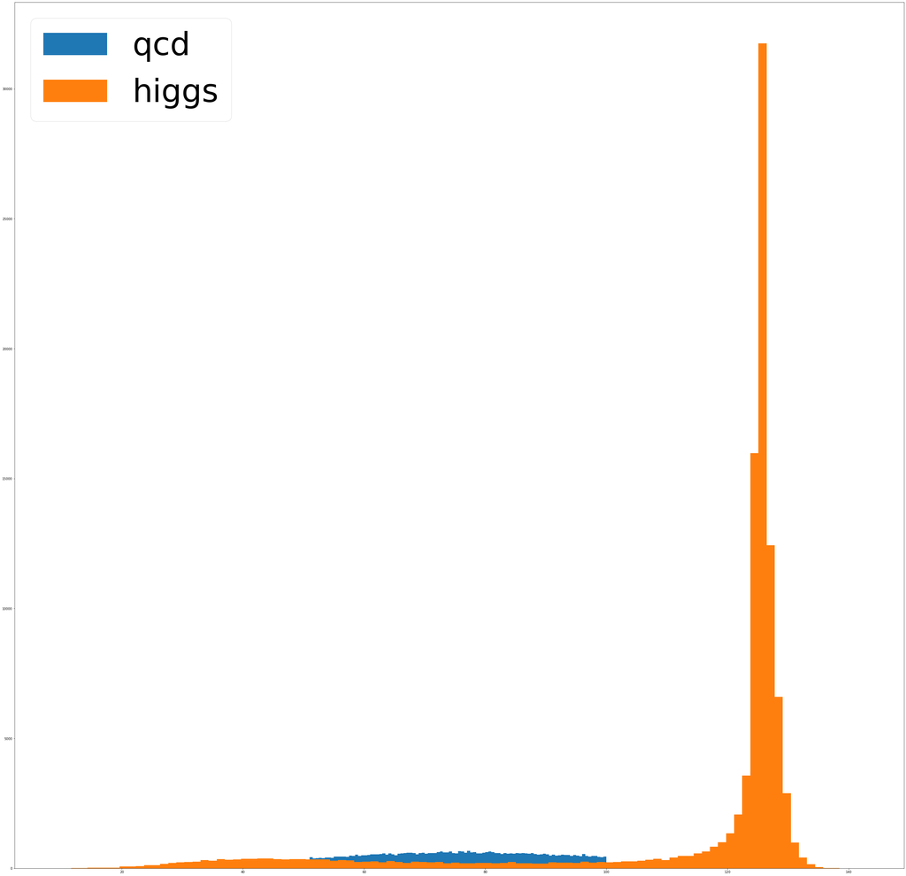

```python
qcd_cut = []
for i in qcd["mass"]:
    if i > 50 and i < 100:
        qcd_cut.append(i)

len(qcd_cut)
fig, ax = plt.subplots(1,1)
qcd_values, qcd_bins, _ = ax.hist(qcd_cut, stacked=True, bins=100, label='qcd')
#ax.hist([qcd_cut, higgs["mass"]], density=True, stacked=True, bins=100)
higgs_values, higgs_bins, _ = ax.hist(higgs["mass"], stacked=True, bins=100, label='higgs')
y = 0

qcd_area = sum(np.diff(qcd_bins)*qcd_values)
higgs_area = sum(np.diff(higgs_bins) * higgs_values)
ax.legend(prop={'size': 100})
print((higgs_area*100/uncut_higgs_area) / math.sqrt(20000 * qcd_area/uncut_qcd_area))

plt.show()
```

To reiterate, I'm calculating the significance by:

1. Finding the area of the uncut qcd and higgs
2. Finding the area of the cut qcd and higgs
3. Finding the fraction cut/uncut
4. cut/uncut * expected yield to get Nqcd and Nhiggs
5. Plug that into the formula Nhiggs/sqrt(Nqcd)

```python
53247/100000 * 20000
```

```
10649.4
```

Oh, this ends up being the same as what we did earlier.

```python
y = 0
for i in range(100):
    y = y + x3[0][i] * x3[1][i]
y
```

```
9617400.329768123
```

```
0.04153825257920488
```

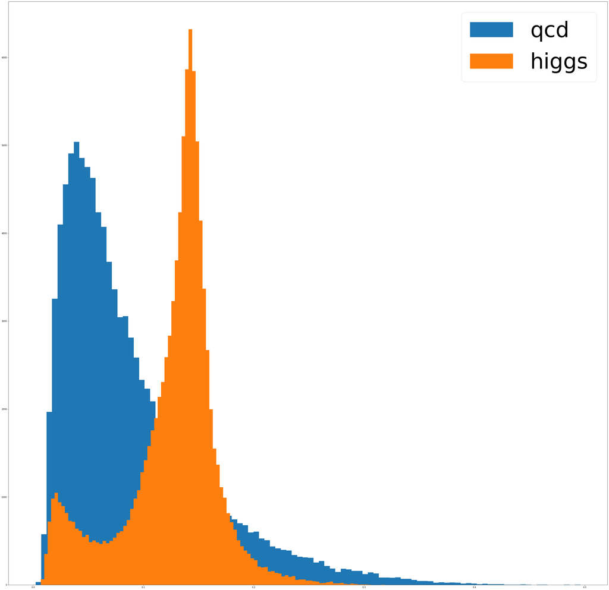

```python
qcd_cut = []
for i in qcd["ee2"]:
    qcd_cut.append(i)

fig, ax = plt.subplots(1,1)
qcd_values, qcd_bins, _ = ax.hist(qcd_cut, bins=100, label='qcd')
#ax.hist([qcd_cut, higgs["mass"]], density=True, stacked=True, bins=100)
higgs_values, higgs_bins, _ = ax.hist(higgs["ee2"], bins=100, label='higgs')
y = 0

qcd_area = sum(np.diff(qcd_bins)*qcd_values)
higgs_area = sum(np.diff(higgs_bins) * higgs_values)
ax.legend(prop={'size': 100})
print((higgs_area*100/uncut_higgs_area) / math.sqrt(20000 * qcd_area/uncut_qcd_area))

plt.show()
```

```
0.17019023138628497
```

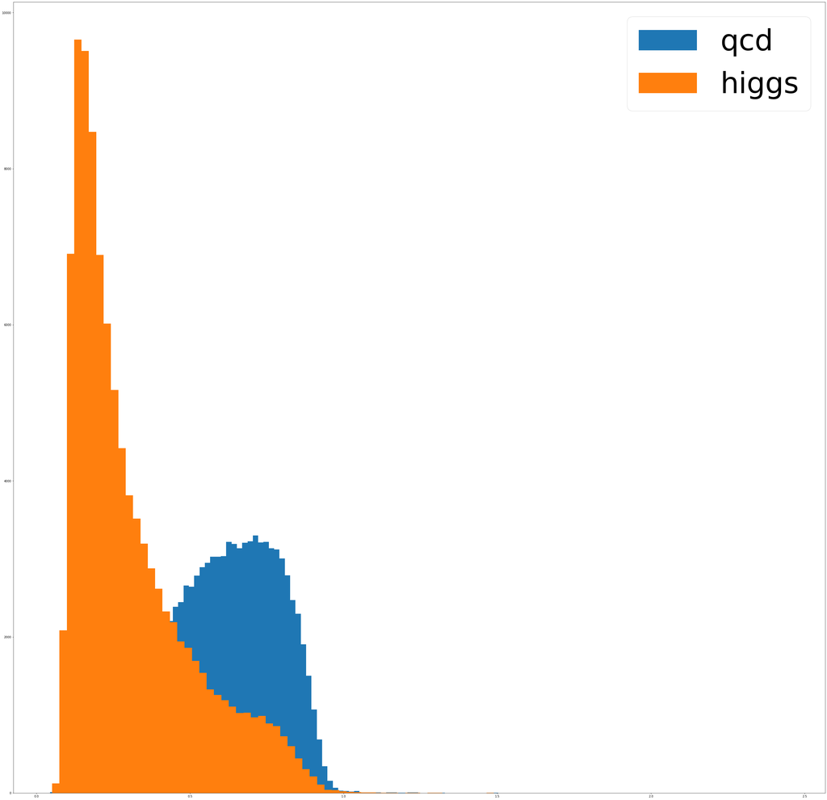

```python
qcd_cut = []
for i in qcd["t2"]:
    qcd_cut.append(i)

len(qcd_cut)
fig, ax = plt.subplots(1,1)
qcd_values, qcd_bins, _ = ax.hist(qcd_cut,  bins=100, label='qcd')
#ax.hist([qcd_cut, higgs["mass"]], density=True, stacked=True, bins=100)
higgs_values, higgs_bins, _ = ax.hist(higgs["t2"], stacked=True, bins=100, label='higgs')

qcd_area = sum(np.diff(qcd_bins)*qcd_values)
higgs_area = sum(np.diff(higgs_bins) * higgs_values)
ax.legend(prop={'size': 100})
print((higgs_area*100/uncut_higgs_area) / math.sqrt(20000 * qcd_area/uncut_qcd_area))


plt.show()
```

```
0.09085363398636459
```

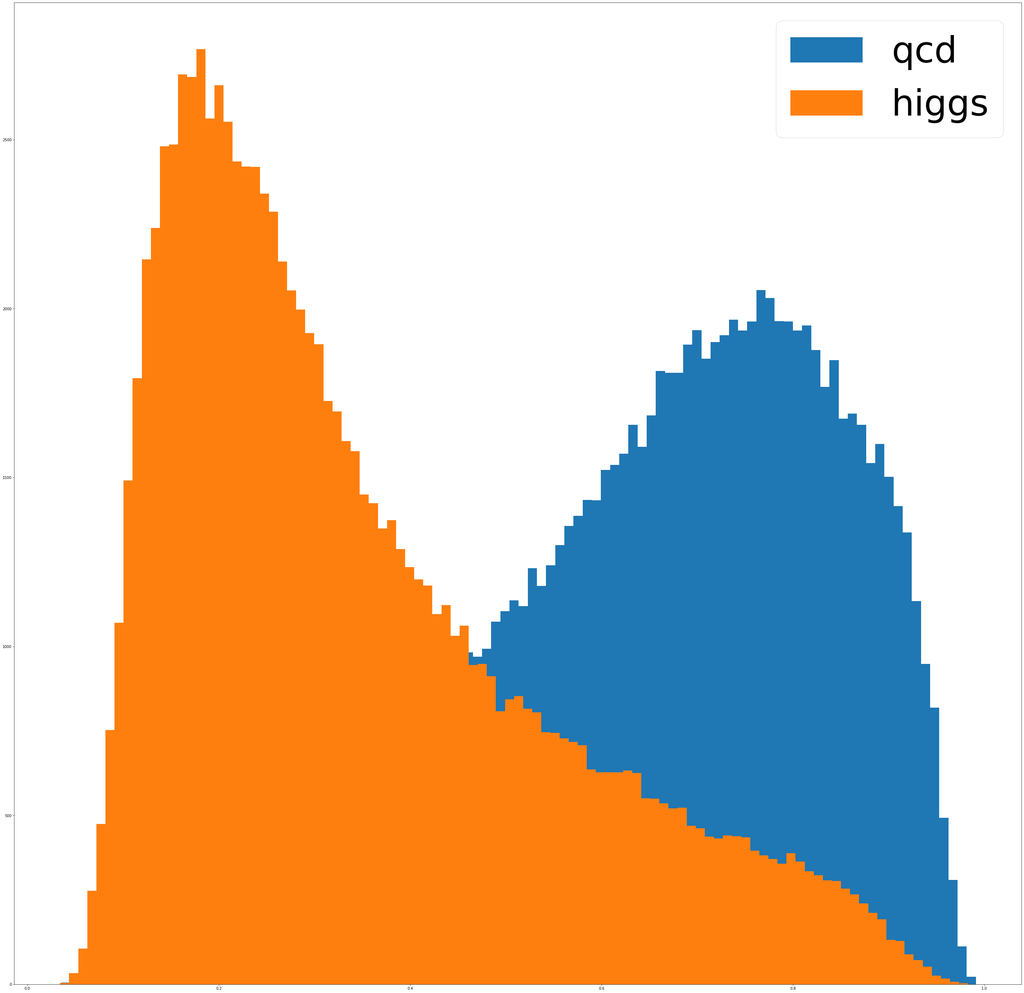

```python
qcd_cut = []
for i in qcd["t21"]:
    qcd_cut.append(i)

len(qcd_cut)
fig, ax = plt.subplots(1,1)
qcd_values, qcd_bins, _ = ax.hist(qcd_cut,  bins=100, label='qcd')
#ax.hist([qcd_cut, higgs["mass"]], density=True, stacked=True, bins=100)
higgs_values, higgs_bins, _ = ax.hist(higgs["t21"],  bins=100, label='higgs')
y = 0

qcd_area = sum(np.diff(qcd_bins)*qcd_values)
higgs_area = sum(np.diff(higgs_bins) * higgs_values)
ax.legend(prop={'size': 100})
print((higgs_area*100/uncut_higgs_area) / math.sqrt(20000 * qcd_area/uncut_qcd_area))

plt.show()
```

In the few graphs above, we explore some potential discriminating factors, without mass cuts. t21 looks promising so let's take a mass cut.

```
0.8266155463269279
```

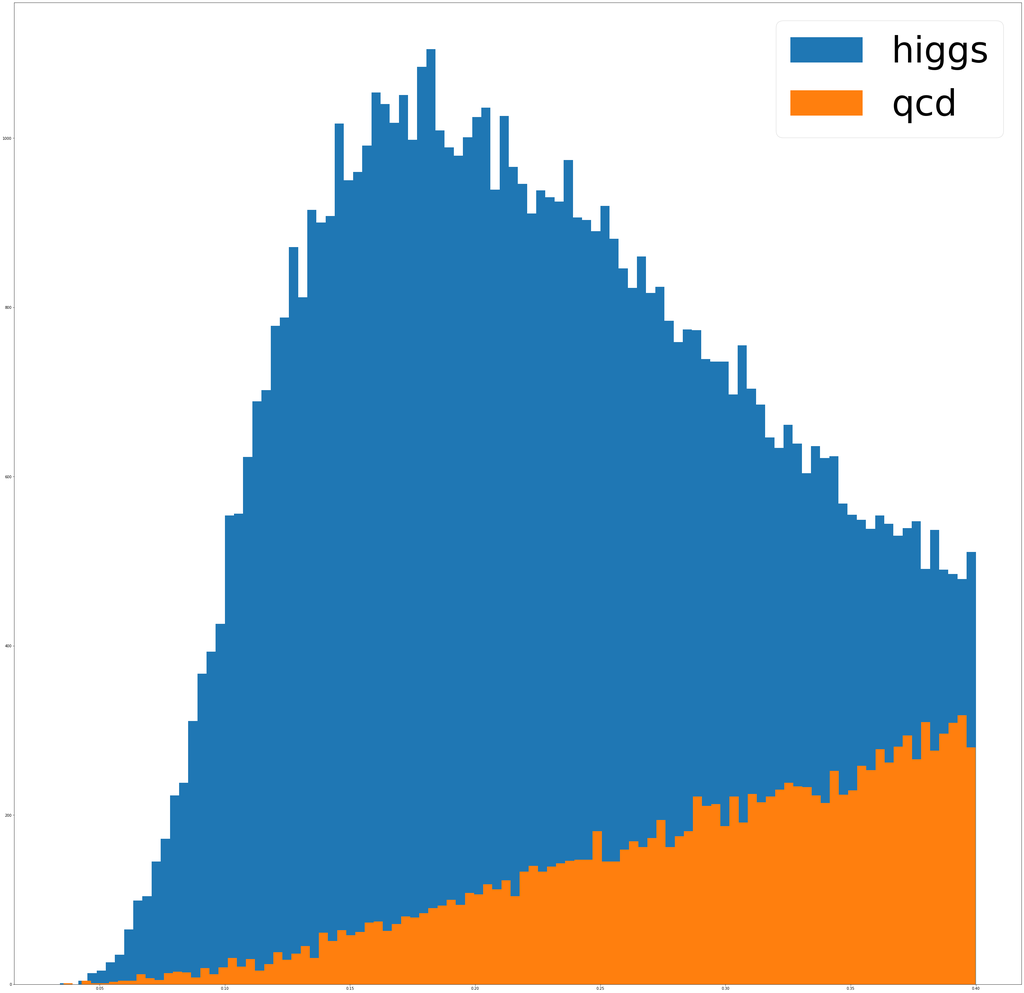

```python
qcd_cut = []
for i in qcd["t21"]:
    if i > 0 and i < 0.4:
        qcd_cut.append(i)

higgs_cut = []
for i in higgs["t21"]:
    if i > 0 and i < 0.4:
        higgs_cut.append(i)

uncut_qcd_values, uncut_qcd_bins, _ = ax.hist(qcd["t21"], bins=100, label='qcd')
uncut_higgs_values, uncut_higgs_bins, _ = ax.hist(higgs["t21"], bins=100, label='higgs')
uncut_qcd_area = sum(np.diff(uncut_qcd_bins)*uncut_qcd_values)
uncut_higgs_area = sum(np.diff(uncut_higgs_bins) * uncut_higgs_values)
fig, ax = plt.subplots(1,1)
higgs_values, higgs_bins, _ = ax.hist(higgs_cut,  bins=100, label='higgs')


qcd_values, qcd_bins, _ = ax.hist(qcd_cut,   bins=100, label='qcd')
#ax.hist([qcd_cut, higgs["mass"]], density=True, stacked=True, bins=100)
y = 0

qcd_area = sum(np.diff(qcd_bins)*qcd_values)
higgs_area = sum(np.diff(higgs_bins) * higgs_values)
ax.legend(prop={'size': 100})
print((higgs_area*100/uncut_higgs_area) / math.sqrt(20000 * qcd_area/uncut_qcd_area))

plt.show()

plt.show()
```

From this other paper https://arxiv.org/pdf/1409.6298.pdf (from Lab 6):

> Signal jets will be characterized by a small value of D(β), while background jets will pre-dominantly have large D2 .

Let's look at d2.

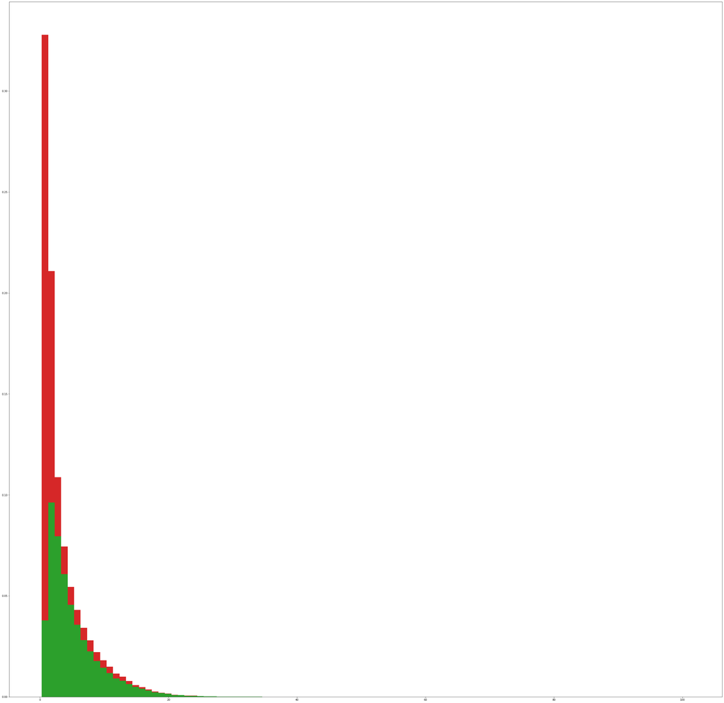

```python
qcd_cut = []
for i in qcd["d2"]:
    qcd_cut.append(i)

len(qcd_cut)
fig, ax = plt.subplots(1,1)
hist2 = ax.hist([qcd_cut, higgs["d2"]], density=True, stacked=True, bins=100)
ax.hist([qcd_cut, higgs["d2"]], density=True, stacked=True, bins=100)

y = 0
z = 0
for i in range(100):
    y = y + hist2[0][0][i] * hist2[1][i]
    z = z + hist2[0][1][i] * hist2[1][i]


plt.show()
```

This doesn't look very discriminating. Let's take a mass cut to see if we can improve the significance.

```
0.5375130317024015
```

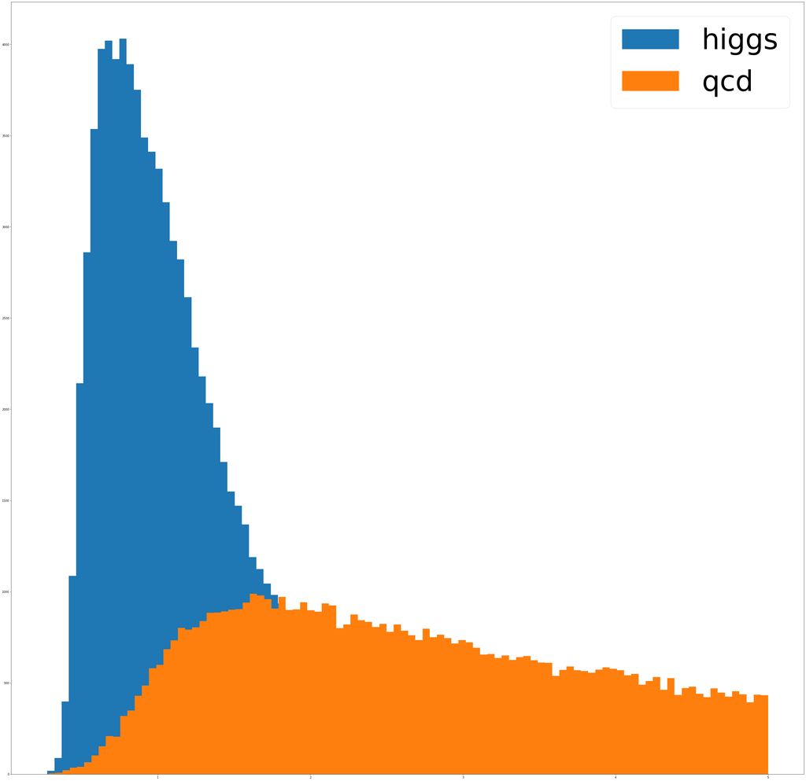

```python
qcd_cut = []
for i in qcd["d2"]:
    if i > 0 and i < 5:
        qcd_cut.append(i)

higgs_cut = []
for i in higgs["d2"]:
    if i > 0 and i < 5:
        higgs_cut.append(i)

uncut_qcd_values, uncut_qcd_bins, _ = ax.hist(qcd["d2"], bins=100, label='qcd')
uncut_higgs_values, uncut_higgs_bins, _ = ax.hist(higgs["d2"], bins=100, label='higgs')
uncut_qcd_area = sum(np.diff(uncut_qcd_bins)*uncut_qcd_values)
uncut_higgs_area = sum(np.diff(uncut_higgs_bins) * uncut_higgs_values)
fig, ax = plt.subplots(1,1)
higgs_values, higgs_bins, _ = ax.hist(higgs_cut,  bins=100, label='higgs')


qcd_values, qcd_bins, _ = ax.hist(qcd_cut,   bins=100, label='qcd')
#ax.hist([qcd_cut, higgs["mass"]], density=True, stacked=True, bins=100)
y = 0

qcd_area = sum(np.diff(qcd_bins)*qcd_values)
higgs_area = sum(np.diff(higgs_bins) * higgs_values)
ax.legend(prop={'size': 100})
print((higgs_area*100/uncut_higgs_area) / math.sqrt(20000 * qcd_area/uncut_qcd_area))

plt.show()

plt.show()
```

```
0.4693316895153545
```

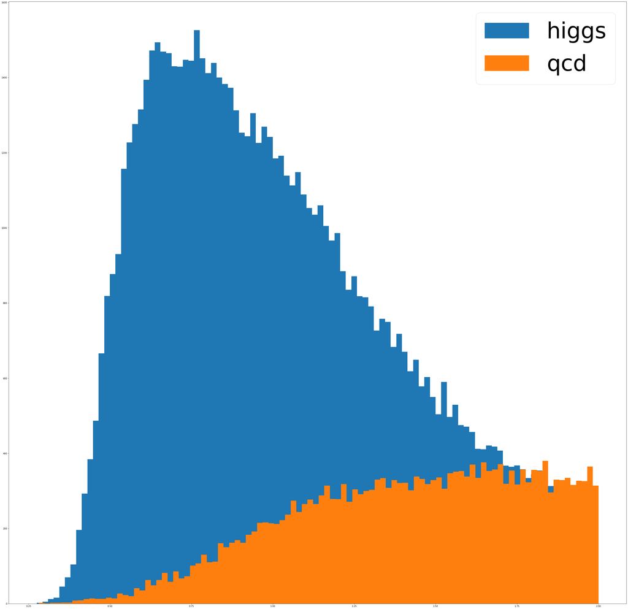

```python
qcd_cut = []
for i in qcd["d2"]:
    if i > 0 and i < 2:
        qcd_cut.append(i)

higgs_cut = []
for i in higgs["d2"]:
    if i > 0 and i < 2:
        higgs_cut.append(i)

uncut_qcd_values, uncut_qcd_bins, _ = ax.hist(qcd["d2"], bins=100, label='qcd')
uncut_higgs_values, uncut_higgs_bins, _ = ax.hist(higgs["d2"], bins=100, label='higgs')
uncut_qcd_area = sum(np.diff(uncut_qcd_bins)*uncut_qcd_values)
uncut_higgs_area = sum(np.diff(uncut_higgs_bins) * uncut_higgs_values)
fig, ax = plt.subplots(1,1)
higgs_values, higgs_bins, _ = ax.hist(higgs_cut,  bins=100, label='higgs')


qcd_values, qcd_bins, _ = ax.hist(qcd_cut,   bins=100, label='qcd')
#ax.hist([qcd_cut, higgs["mass"]], density=True, stacked=True, bins=100)
y = 0

qcd_area = sum(np.diff(qcd_bins)*qcd_values)
higgs_area = sum(np.diff(higgs_bins) * higgs_values)
ax.legend(prop={'size': 100})
print((higgs_area*100/uncut_higgs_area) / math.sqrt(20000 * qcd_area/uncut_qcd_area))

plt.show()

plt.show()
```

```
0.9374792682963194
```

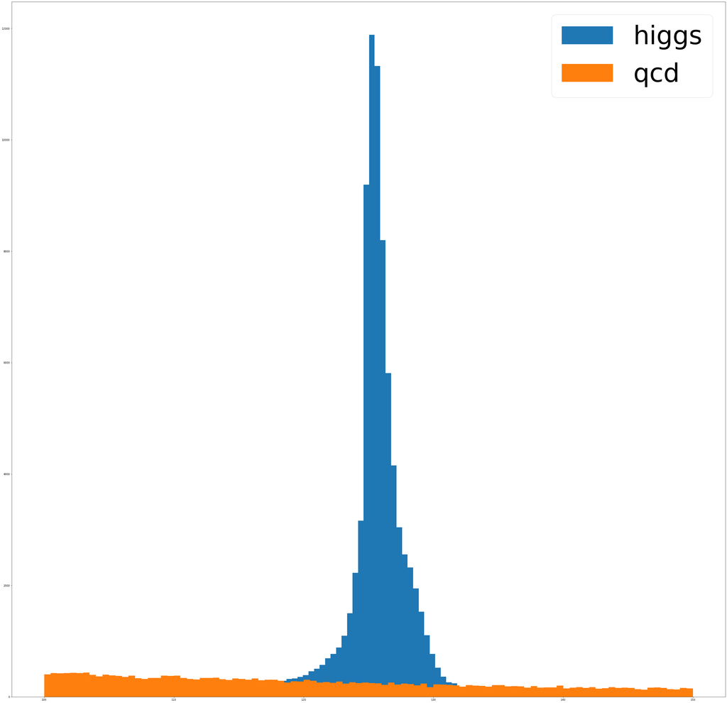

```python
qcd_cut = []
for i in qcd["mass"]:
    if i > 100 and i < 150:
        qcd_cut.append(i)

higgs_cut = []
for i in higgs["mass"]:
    if i > 100 and i < 150:
        higgs_cut.append(i)

uncut_qcd_values, uncut_qcd_bins, _ = ax.hist(qcd["mass"], bins=100, label='qcd')
uncut_higgs_values, uncut_higgs_bins, _ = ax.hist(higgs["mass"], bins=100, label='higgs')
uncut_qcd_area = sum(np.diff(uncut_qcd_bins)*uncut_qcd_values)
uncut_higgs_area = sum(np.diff(uncut_higgs_bins) * uncut_higgs_values)
fig, ax = plt.subplots(1,1)
higgs_values, higgs_bins, _ = ax.hist(higgs_cut,  bins=100, label='higgs')


qcd_values, qcd_bins, _ = ax.hist(qcd_cut,   bins=100, label='qcd')
#ax.hist([qcd_cut, higgs["mass"]], density=True, stacked=True, bins=100)
y = 0

qcd_area = sum(np.diff(qcd_bins)*qcd_values)
higgs_area = sum(np.diff(higgs_bins) * higgs_values)
ax.legend(prop={'size': 100})
print((higgs_area*100/uncut_higgs_area) / math.sqrt(20000 * qcd_area/uncut_qcd_area))

plt.show()

plt.show()
```

## Lab 8 problem 1: high luminosity data

```python
import h5py
hf = h5py.File('data_highLumi_pt_250_500.h5', 'r')
print(hf.keys())
data = np.array(hf.get('data/block0_items/'))
print(data)
data2 = np.array(hf.get('data/block0_values'))
print(data2.shape)
hf.close()
```

```
<KeysViewHDF5 ['data']>
[b'pt' b'eta' b'phi' b'mass' b'ee2' b'ee3' b'd2' b'angularity' b't1' b't2'
 b't3' b't21' b't32' b'KtDeltaR']
(40344, 14)
```

```python
data2[:,3]
```

```
array([ 58.54071353, 109.26143237,  80.39806494, ...,  55.30258594,
        72.33390022, 116.18976981])
```

```
0.7071067811865475
```

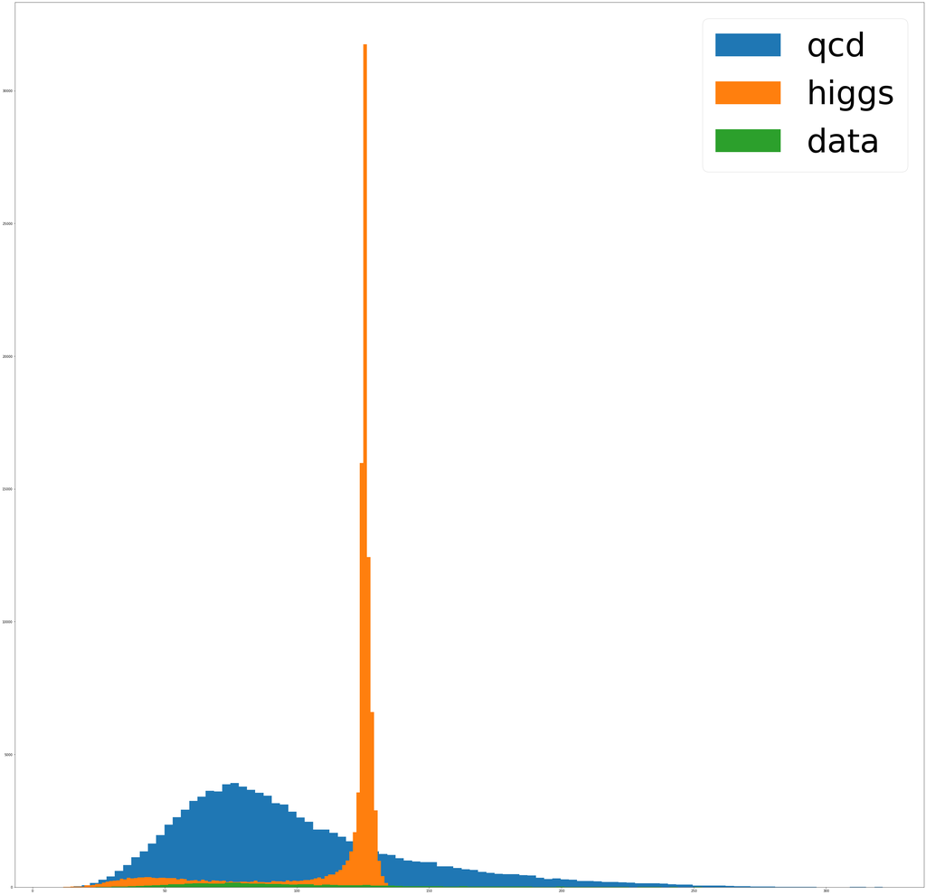

```python
qcd_cut = []
for i in qcd["mass"]:
    #if i > 100 and i < 150:
    if True:
        qcd_cut.append(i)

higgs_cut = []
for i in higgs["mass"]:
    #if i > 100 and i < 150:
    if True:
        higgs_cut.append(i)

data_cut = []
for i in data2[:,3]:
    #if i > 100 and i < 150:
    if True:
        data_cut.append(i)

uncut_qcd_values, uncut_qcd_bins, _ = ax.hist(qcd["mass"], bins=100, label='qcd')
uncut_higgs_values, uncut_higgs_bins, _ = ax.hist(higgs["mass"], bins=100, label='higgs')
uncut_qcd_area = sum(np.diff(uncut_qcd_bins)*uncut_qcd_values)
uncut_higgs_area = sum(np.diff(uncut_higgs_bins) * uncut_higgs_values)
uncut_data_values, uncut_data_bins, _ = ax.hist(data2[:,3], bins=100, label='data')
uncut_data_area = sum(np.diff(uncut_data_bins) * uncut_data_values)
fig, ax = plt.subplots(1,1)
qcd_values, qcd_bins, _ = ax.hist(qcd_cut,   bins=100, label='qcd')



higgs_values, higgs_bins, _ = ax.hist(higgs_cut, bins=100, label='higgs')
data_values, data_bins, _ = ax.hist(data_cut,  bins=100, label='data')


#ax.hist([qcd_cut, higgs["mass"]], density=True, stacked=True, bins=100)
y = 0

qcd_area = sum(np.diff(qcd_bins)*qcd_values)
higgs_area = sum(np.diff(higgs_bins) * higgs_values)
data_area = sum(np.diff(data_bins) * data_values)
ax.legend(prop={'size': 100})
print((higgs_area*100/uncut_higgs_area) / math.sqrt(20000 * data_area/uncut_data_area))

plt.show()
```

```
0.906514846634722
```

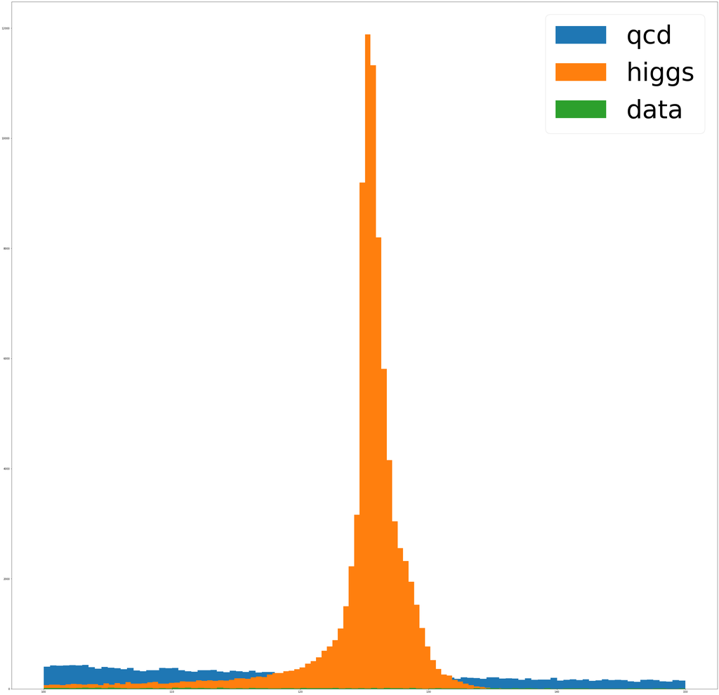

```python
qcd_cut = []
for i in qcd["mass"]:
    if i > 100 and i < 150:
    #if True:
        qcd_cut.append(i)

higgs_cut = []
for i in higgs["mass"]:
    if i > 100 and i < 150:
    #if True:
        higgs_cut.append(i)

data_cut = []
for i in data2[:,3]:
    if i > 100 and i < 150:
        data_cut.append(i)

uncut_qcd_values, uncut_qcd_bins, _ = ax.hist(qcd["mass"], bins=100, label='qcd')
uncut_higgs_values, uncut_higgs_bins, _ = ax.hist(higgs["mass"], bins=100, label='higgs')
uncut_qcd_area = sum(np.diff(uncut_qcd_bins)*uncut_qcd_values)
uncut_higgs_area = sum(np.diff(uncut_higgs_bins) * uncut_higgs_values)
uncut_data_values, uncut_data_bins, _ = ax.hist(data2[:,3], bins=100, label='data')
uncut_data_area = sum(np.diff(uncut_data_bins) * uncut_data_values)
fig, ax = plt.subplots(1,1)
qcd_values, qcd_bins, _ = ax.hist(qcd_cut,   bins=100, label='qcd')



higgs_values, higgs_bins, _ = ax.hist(higgs_cut, bins=100, label='higgs')
data_values, data_bins, _ = ax.hist(data_cut,  bins=100, label='data')


#ax.hist([qcd_cut, higgs["mass"]], density=True, stacked=True, bins=100)
y = 0

qcd_area = sum(np.diff(qcd_bins)*qcd_values)
higgs_area = sum(np.diff(higgs_bins) * higgs_values)
data_area = sum(np.diff(data_bins) * data_values)
ax.legend(prop={'size': 100})
print((higgs_area*100/uncut_higgs_area) / math.sqrt(20000 * data_area/uncut_data_area))

plt.show()
```

t21 cut:

```
0.8653203820391595
```

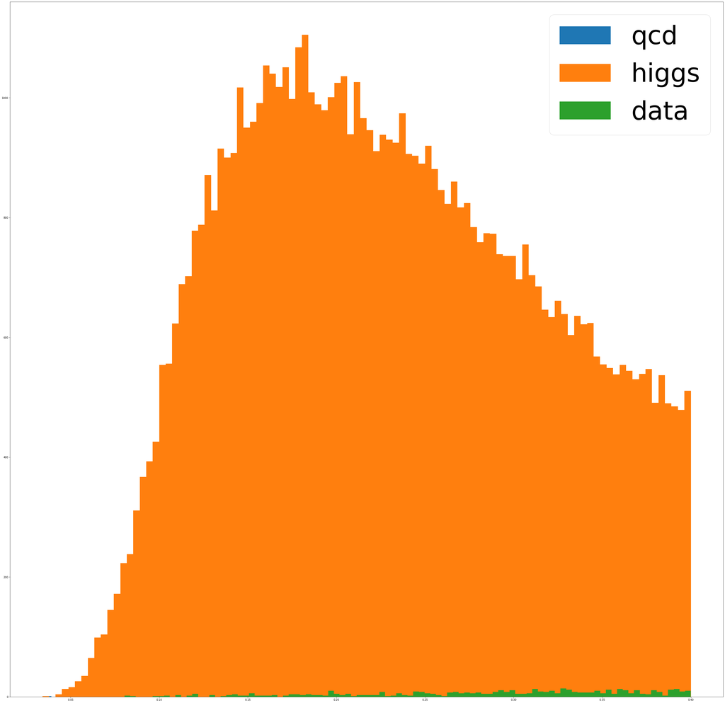

```python
qcd_cut = []
for i in qcd["t21"]:
    if i > 0 and i < 0.4:
        qcd_cut.append(i)

higgs_cut = []
for i in higgs["t21"]:
    if i > 0 and i < 0.4:
        higgs_cut.append(i)

data_cut = []
for i in data2[:,11]:
    if i > 0 and i < 0.4:
        data_cut.append(i)

uncut_qcd_values, uncut_qcd_bins, _ = ax.hist(qcd["t21"], bins=100, label='qcd')
uncut_higgs_values, uncut_higgs_bins, _ = ax.hist(higgs["t21"], bins=100, label='higgs')
uncut_qcd_area = sum(np.diff(uncut_qcd_bins)*uncut_qcd_values)
uncut_higgs_area = sum(np.diff(uncut_higgs_bins) * uncut_higgs_values)
uncut_data_values, uncut_data_bins, _ = ax.hist(data2[:,11], bins=100, label='data')
uncut_data_area = sum(np.diff(uncut_data_bins) * uncut_data_values)
fig, ax = plt.subplots(1,1)
qcd_values, qcd_bins, _ = ax.hist(qcd_cut,   bins=100, label='qcd')



higgs_values, higgs_bins, _ = ax.hist(higgs_cut, bins=100, label='higgs')
data_values, data_bins, _ = ax.hist(data_cut,  bins=100, label='data')


#ax.hist([qcd_cut, higgs["mass"]], density=True, stacked=True, bins=100)
y = 0

qcd_area = sum(np.diff(qcd_bins)*qcd_values)
higgs_area = sum(np.diff(higgs_bins) * higgs_values)
data_area = sum(np.diff(data_bins) * data_values)
ax.legend(prop={'size': 100})
print((higgs_area*100/uncut_higgs_area) / math.sqrt(20000 * data_area/uncut_data_area))

plt.show()
```

d2 uncut:

```
0.7071067811865475
```

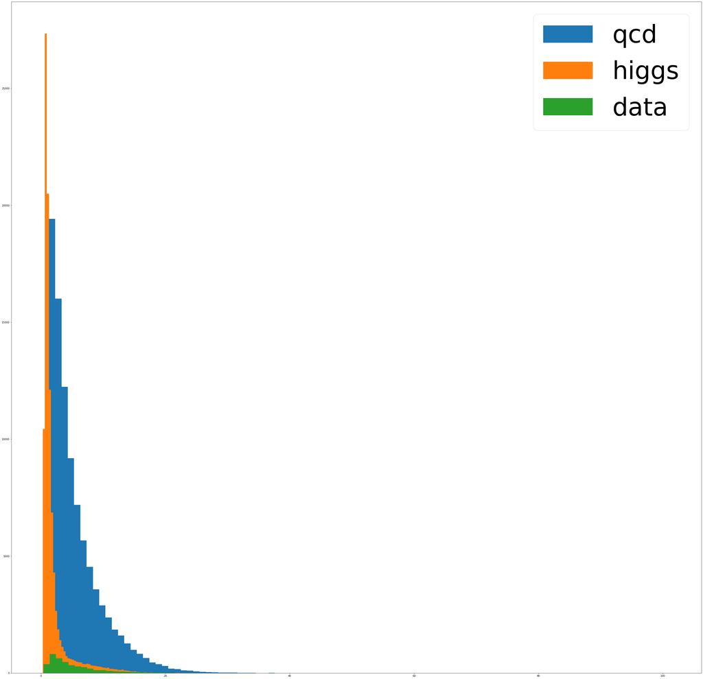

```python
qcd_cut = []
for i in qcd["d2"]:
    #if i > 0 and i < 2:
    if True:
        qcd_cut.append(i)

higgs_cut = []
for i in higgs["d2"]:
    #if i > 0 and i < 2:
    if True:
        higgs_cut.append(i)

data_cut = []
for i in data2[:,6]:
    if True:
        data_cut.append(i)

uncut_qcd_values, uncut_qcd_bins, _ = ax.hist(qcd["d2"], bins=100, label='qcd')
uncut_higgs_values, uncut_higgs_bins, _ = ax.hist(higgs["d2"], bins=100, label='higgs')
uncut_qcd_area = sum(np.diff(uncut_qcd_bins)*uncut_qcd_values)
uncut_higgs_area = sum(np.diff(uncut_higgs_bins) * uncut_higgs_values)
uncut_data_values, uncut_data_bins, _ = ax.hist(data2[:,6], bins=100, label='data')
uncut_data_area = sum(np.diff(uncut_data_bins) * uncut_data_values)
fig, ax = plt.subplots(1,1)
qcd_values, qcd_bins, _ = ax.hist(qcd_cut,   bins=100, label='qcd')



higgs_values, higgs_bins, _ = ax.hist(higgs_cut, bins=100, label='higgs')
data_values, data_bins, _ = ax.hist(data_cut,  bins=100, label='data')


#ax.hist([qcd_cut, higgs["mass"]], density=True, stacked=True, bins=100)
y = 0

qcd_area = sum(np.diff(qcd_bins)*qcd_values)
higgs_area = sum(np.diff(higgs_bins) * higgs_values)
data_area = sum(np.diff(data_bins) * data_values)
ax.legend(prop={'size': 100})
print((higgs_area*100/uncut_higgs_area) / math.sqrt(20000 * data_area/uncut_data_area))

plt.show()
```

d2 cut:

```
0.4901556089625626
```

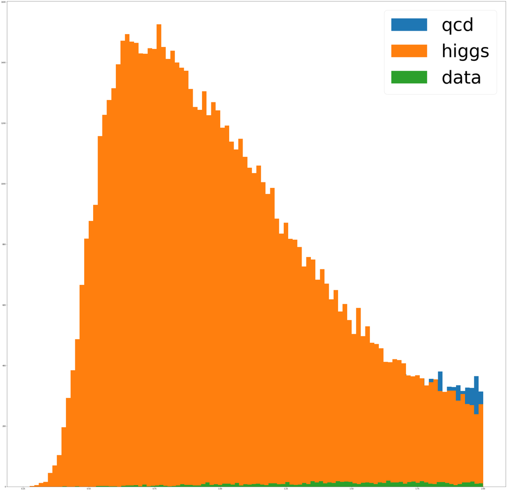

```python
qcd_cut = []
for i in qcd["d2"]:
    if i > 0 and i < 2:
    #if True:
        qcd_cut.append(i)

higgs_cut = []
for i in higgs["d2"]:
    if i > 0 and i < 2:
    #if True:
        higgs_cut.append(i)

data_cut = []
for i in data2[:,6]:
    if i > 0 and i < 2:
        data_cut.append(i)

uncut_qcd_values, uncut_qcd_bins, _ = ax.hist(qcd["d2"], bins=100, label='qcd')
uncut_higgs_values, uncut_higgs_bins, _ = ax.hist(higgs["d2"], bins=100, label='higgs')
uncut_qcd_area = sum(np.diff(uncut_qcd_bins)*uncut_qcd_values)
uncut_higgs_area = sum(np.diff(uncut_higgs_bins) * uncut_higgs_values)
uncut_data_values, uncut_data_bins, _ = ax.hist(data2[:,6], bins=100, label='data')
uncut_data_area = sum(np.diff(uncut_data_bins) * uncut_data_values)
fig, ax = plt.subplots(1,1)
qcd_values, qcd_bins, _ = ax.hist(qcd_cut,   bins=100, label='qcd')



higgs_values, higgs_bins, _ = ax.hist(higgs_cut, bins=100, label='higgs')
data_values, data_bins, _ = ax.hist(data_cut,  bins=100, label='data')


#ax.hist([qcd_cut, higgs["mass"]], density=True, stacked=True, bins=100)
y = 0

qcd_area = sum(np.diff(qcd_bins)*qcd_values)
higgs_area = sum(np.diff(higgs_bins) * higgs_values)
data_area = sum(np.diff(data_bins) * data_values)
ax.legend(prop={'size': 100})
print((higgs_area*100/uncut_higgs_area) / math.sqrt(20000 * data_area/uncut_data_area))

plt.show()
```

The significance is low because the high luminosity data set looks a lot like the background data set. Hence the N(high luminosity) / N(Qcd) is low.

## Problem 2: Low luminosity data

```python
import h5py
hf = h5py.File('data_lowLumi_pt_250_500.h5', 'r')
print(hf.keys())
data = np.array(hf.get('data/block0_items/'))
print(data)
data2 = np.array(hf.get('data/block0_values'))
print(data2.shape)
hf.close()
```

```
<KeysViewHDF5 ['data']>
[b'pt' b'eta' b'phi' b'mass' b'ee2' b'ee3' b'd2' b'angularity' b't1' b't2'
 b't3' b't21' b't32' b'KtDeltaR']
(4060, 14)
```

Mass uncut:

```
0.7071067811865475
```

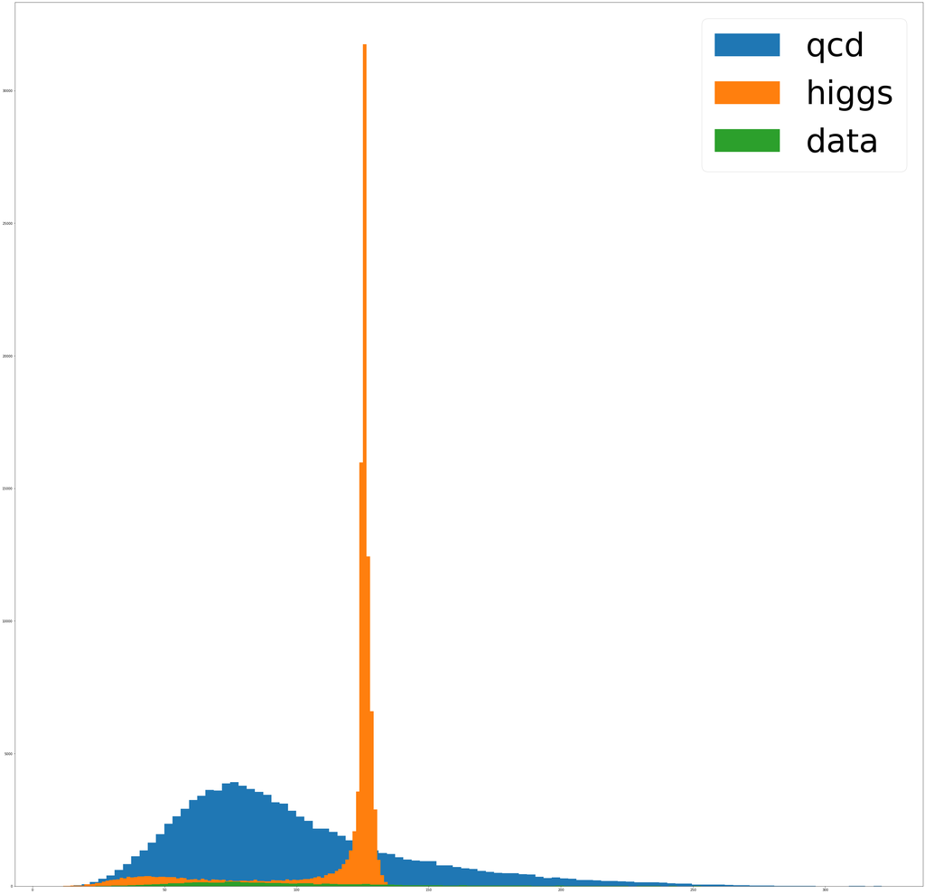

```python
qcd_cut = []
for i in qcd["mass"]:
    #if i > 100 and i < 150:
    if True:
        qcd_cut.append(i)

higgs_cut = []
for i in higgs["mass"]:
    #if i > 100 and i < 150:
    if True:
        higgs_cut.append(i)

data_cut = []
for i in data2[:,3]:
    #if i > 100 and i < 150:
    if True:
        data_cut.append(i)

uncut_qcd_values, uncut_qcd_bins, _ = ax.hist(qcd["mass"], bins=100, label='qcd')
uncut_higgs_values, uncut_higgs_bins, _ = ax.hist(higgs["mass"], bins=100, label='higgs')
uncut_qcd_area = sum(np.diff(uncut_qcd_bins)*uncut_qcd_values)
uncut_higgs_area = sum(np.diff(uncut_higgs_bins) * uncut_higgs_values)
uncut_data_values, uncut_data_bins, _ = ax.hist(data2[:,3], bins=100, label='data')
uncut_data_area = sum(np.diff(uncut_data_bins) * uncut_data_values)
fig, ax = plt.subplots(1,1)
qcd_values, qcd_bins, _ = ax.hist(qcd_cut,   bins=100, label='qcd')



higgs_values, higgs_bins, _ = ax.hist(higgs_cut, bins=100, label='higgs')
data_values, data_bins, _ = ax.hist(data_cut,  bins=100, label='data')


#ax.hist([qcd_cut, higgs["mass"]], density=True, stacked=True, bins=100)
y = 0

qcd_area = sum(np.diff(qcd_bins)*qcd_values)
higgs_area = sum(np.diff(higgs_bins) * higgs_values)
data_area = sum(np.diff(data_bins) * data_values)
ax.legend(prop={'size': 100})
print((higgs_area*100/uncut_higgs_area) / math.sqrt(20000 * data_area/uncut_data_area))

plt.show()

plt.show()
```

Mass cut:

```
0.920935733789938
```

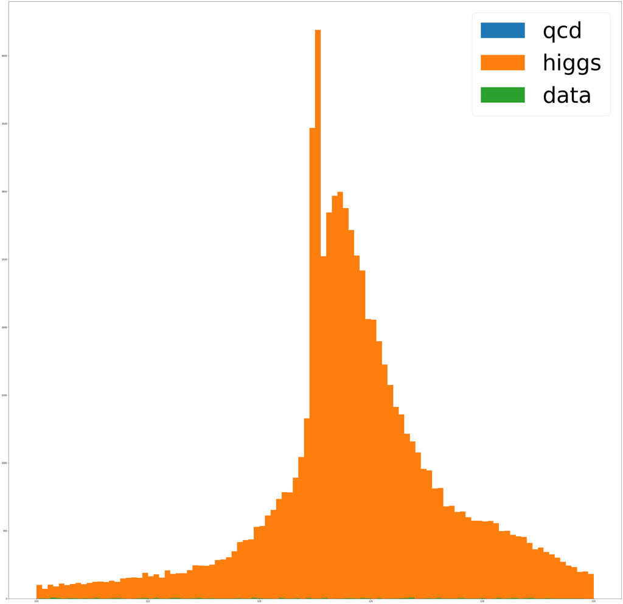

```python
qcd_cut = []
for i in qcd["mass"]:
    if i > 120 and i < 130:
    #if True:
        qcd_cut.append(i)

higgs_cut = []
for i in higgs["mass"]:
    if i > 120 and i < 130:
    #if True:
        higgs_cut.append(i)

data_cut = []
for i in data2[:,3]:
    if i > 120 and i < 130:
        data_cut.append(i)

uncut_qcd_values, uncut_qcd_bins, _ = ax.hist(qcd["mass"], bins=100, label='qcd')
uncut_higgs_values, uncut_higgs_bins, _ = ax.hist(higgs["mass"], bins=100, label='higgs')
uncut_qcd_area = sum(np.diff(uncut_qcd_bins)*uncut_qcd_values)
uncut_higgs_area = sum(np.diff(uncut_higgs_bins) * uncut_higgs_values)
uncut_data_values, uncut_data_bins, _ = ax.hist(data2[:,3], bins=100, label='data')
uncut_data_area = sum(np.diff(uncut_data_bins) * uncut_data_values)
fig, ax = plt.subplots(1,1)
qcd_values, qcd_bins, _ = ax.hist(qcd_cut,   bins=100, label='qcd')



higgs_values, higgs_bins, _ = ax.hist(higgs_cut, bins=100, label='higgs')
data_values, data_bins, _ = ax.hist(data_cut,  bins=100, label='data')


#ax.hist([qcd_cut, higgs["mass"]], density=True, stacked=True, bins=100)
y = 0

qcd_area = sum(np.diff(qcd_bins)*qcd_values)
higgs_area = sum(np.diff(higgs_bins) * higgs_values)
data_area = sum(np.diff(data_bins) * data_values)
ax.legend(prop={'size': 100})
print((higgs_area*100/uncut_higgs_area) / math.sqrt(20000 * data_area/uncut_data_area))

plt.show()
```

t21 uncut:

```
0.7071067811865475
```

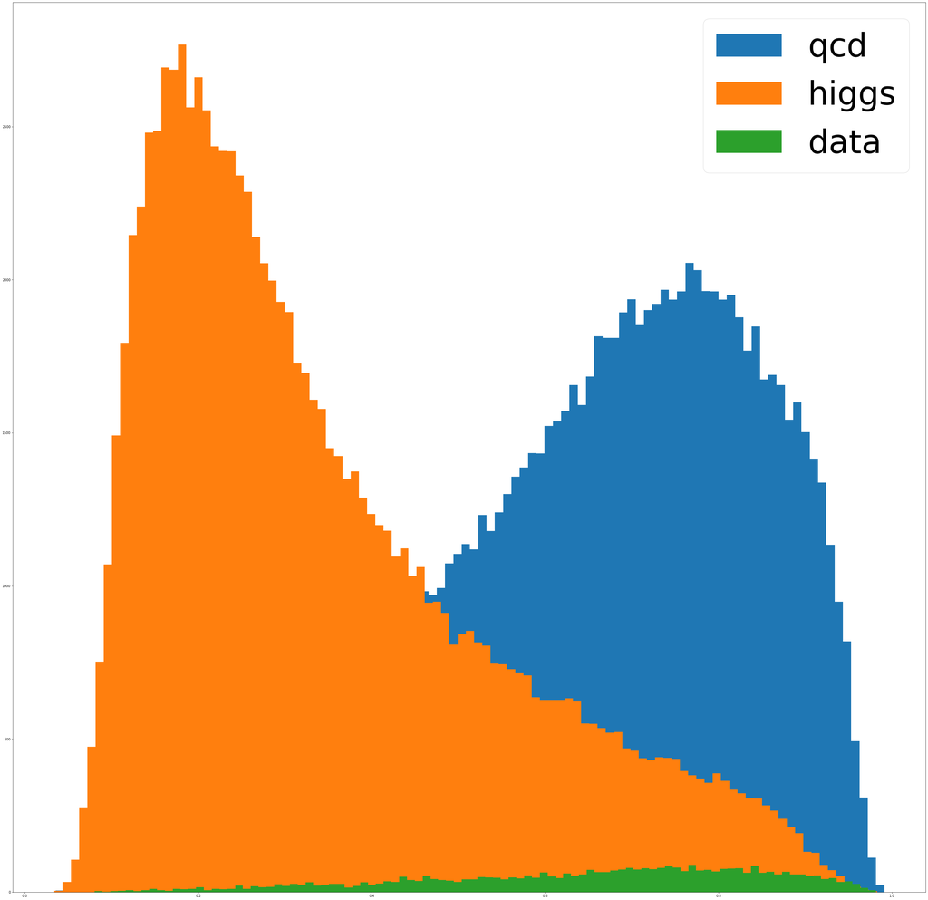

```python
qcd_cut = []
for i in qcd["t21"]:
    #if i > 0 and i < 0.4:
    if True:
        qcd_cut.append(i)

higgs_cut = []
for i in higgs["t21"]:
    #if i > 0 and i < 0.4:
    if True:
        higgs_cut.append(i)

data_cut = []
for i in data2[:,11]:
    if True:
    #if i > 0 and i < 0.4:
        data_cut.append(i)

uncut_qcd_values, uncut_qcd_bins, _ = ax.hist(qcd["t21"], bins=100, label='qcd')
uncut_higgs_values, uncut_higgs_bins, _ = ax.hist(higgs["t21"], bins=100, label='higgs')
uncut_qcd_area = sum(np.diff(uncut_qcd_bins)*uncut_qcd_values)
uncut_higgs_area = sum(np.diff(uncut_higgs_bins) * uncut_higgs_values)
uncut_data_values, uncut_data_bins, _ = ax.hist(data2[:,11], bins=100, label='data')
uncut_data_area = sum(np.diff(uncut_data_bins) * uncut_data_values)
fig, ax = plt.subplots(1,1)
qcd_values, qcd_bins, _ = ax.hist(qcd_cut,   bins=100, label='qcd')



higgs_values, higgs_bins, _ = ax.hist(higgs_cut, bins=100, label='higgs')
data_values, data_bins, _ = ax.hist(data_cut,  bins=100, label='data')


#ax.hist([qcd_cut, higgs["mass"]], density=True, stacked=True, bins=100)
y = 0

qcd_area = sum(np.diff(qcd_bins)*qcd_values)
higgs_area = sum(np.diff(higgs_bins) * higgs_values)
data_area = sum(np.diff(data_bins) * data_values)
ax.legend(prop={'size': 100})
print((higgs_area*100/uncut_higgs_area) / math.sqrt(20000 * data_area/uncut_data_area))

plt.show()
```

t21 cut:

[output not shown]

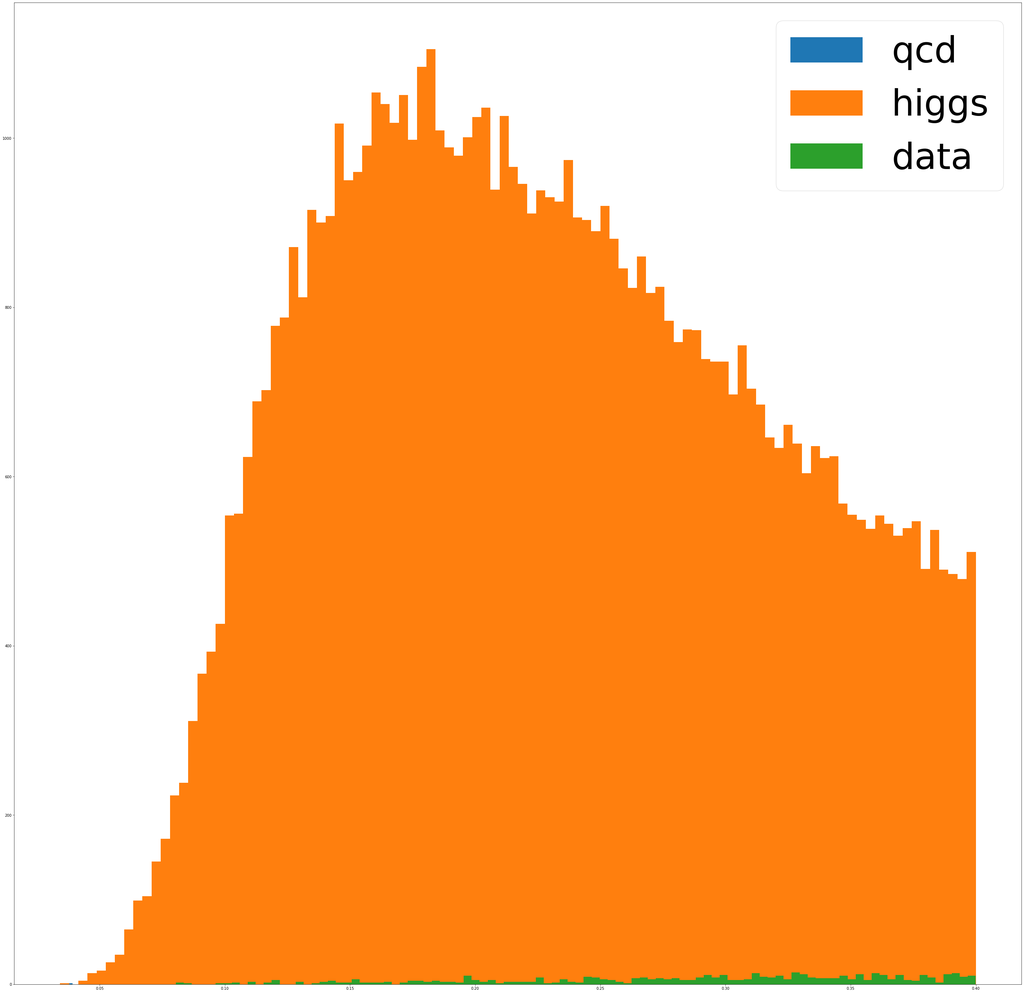

```python
qcd_cut = []
for i in qcd["t21"]:
    if i > 0 and i < 0.4:
        qcd_cut.append(i)

higgs_cut = []
for i in higgs["t21"]:
    if i > 0 and i < 0.4:
        higgs_cut.append(i)

data_cut = []
for i in data2[:,11]:
    if i > 0 and i < 0.4:
        data_cut.append(i)

uncut_qcd_values, uncut_qcd_bins, _ = ax.hist(qcd["t21"], bins=100, label='qcd')
uncut_higgs_values, uncut_higgs_bins, _ = ax.hist(higgs["t21"], bins=100, label='higgs')
uncut_qcd_area = sum(np.diff(uncut_qcd_bins)*uncut_qcd_values)
uncut_higgs_area = sum(np.diff(uncut_higgs_bins) * uncut_higgs_values)
uncut_data_values, uncut_data_bins, _ = ax.hist(data2[:,11], bins=100, label='data')
uncut_data_area = sum(np.diff(uncut_data_bins) * uncut_data_values)
fig, ax = plt.subplots(1,1)
qcd_values, qcd_bins, _ = ax.hist(qcd_cut,   bins=100, label='qcd')



higgs_values, higgs_bins, _ = ax.hist(higgs_cut, bins=100, label='higgs')
data_values, data_bins, _ = ax.hist(data_cut,  bins=100, label='data')


#ax.hist([qcd_cut, higgs["mass"]], density=True, stacked=True, bins=100)
y = 0

qcd_area = sum(np.diff(qcd_bins)*qcd_values)
higgs_area = sum(np.diff(higgs_bins) * higgs_values)
data_area = sum(np.diff(data_bins) * data_values)
ax.legend(prop={'size': 100})
print((higgs_area*100/uncut_higgs_area) / math.sqrt(20000 * data_area/uncut_data_area))

plt.show()
```

The significance is similar.